# Elizabeth Public Schools — NJ School Data Almanac – NJ District Profiles

NJ School Data Almanac

Elizabeth Public Schools

UNION COUNTY · TRADITIONAL PUBLIC DISTRICT · DFG A · 26,708 STUDENTS (2026)

26,708

Students

88.4%

4-yr grad rate

43.9%

Gr 3-8 ELA

15.8%

Chronically absent

$20,203

Per pupil

*10 things the data says about Elizabeth Public Schools. Every figure is computed from New Jersey Department of Education data via the njschooldata package — nothing is estimated. Comparisons use District Factor Group (DFG) peers (39 districts in DFG A).*

No. 1 ACHIEVEMENT

## Half of Elizabeth’s Seniors Pass an AP Exam — But Only a Quarter of Its Younger Grades Are Proficient in Math

In 2024, 52.9% of Elizabeth students earned a 3+ on an AP exam, yet just 26.7% of students in grades 3-8 reached proficiency in math on the NJSLA.

Elizabeth’s high school produces college-credit results that few districts of any income level match: in 2024, 52.9% of its students scored a 3 or higher on an Advanced Placement exam or a 4 or higher on an International Baccalaureate exam. But the foundation beneath that headline tells a more complicated story. In the same year, only 26.7% of Elizabeth’s students in grades 3 through 8 were proficient in math on the NJSLA, and 43.9% were proficient in English language arts.

The distance between those numbers is the district’s central tension. The elite end of the pipeline — AP and IB coursework that nearly every senior takes — is clearing bars at twice the state rate, while the elementary and middle grades that feed it sit below half-proficiency in reading and barely above a quarter in math. Even at the high school level, the gap persists by subject: 71.2% of students cleared the NJGPA bar in ELA in 2025 but 48.3% in math.

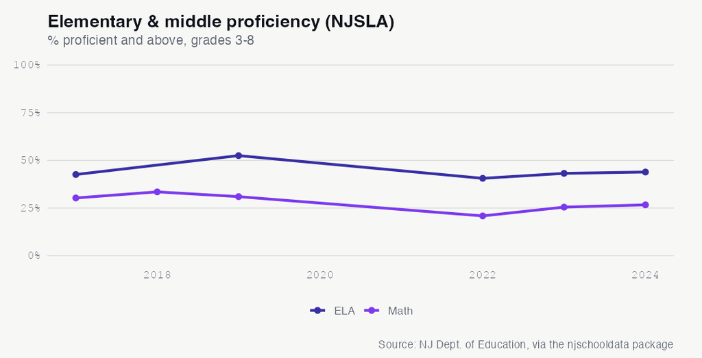

See the underlying data ›

No. 2 ACHIEVEMENT

## Elizabeth’s Grade 3-8 Reading Proficiency Is Still 9 Points Below Where It Was Before COVID

NJSLA ELA proficiency in grades 3-8 fell from 52.5% in 2019 to 40.6% in 2022 and has recovered only to 43.9% by 2024.

Before the pandemic, more than half of Elizabeth’s students in grades 3 through 8 read at grade level: ELA proficiency on the NJSLA stood at 52.5% in 2019. The pandemic erased much of that ground. By 2022, when testing resumed, proficiency had dropped to 40.6% — an 11.9-point fall. Two years of recovery have followed, but slowly: the rate rose to 43.2% in 2023 and 43.9% in 2024, leaving the district still 8.6 points short of its 2019 mark.

Elizabeth is not alone in carrying a pandemic deficit, but the pace of its rebound is the open question. At under a point of ELA gain per year, the district’s grade 3-8 reading proficiency would not return to its 2019 level for nearly a decade. Whether that recovery accelerates is what the next round of NJSLA results will reveal.

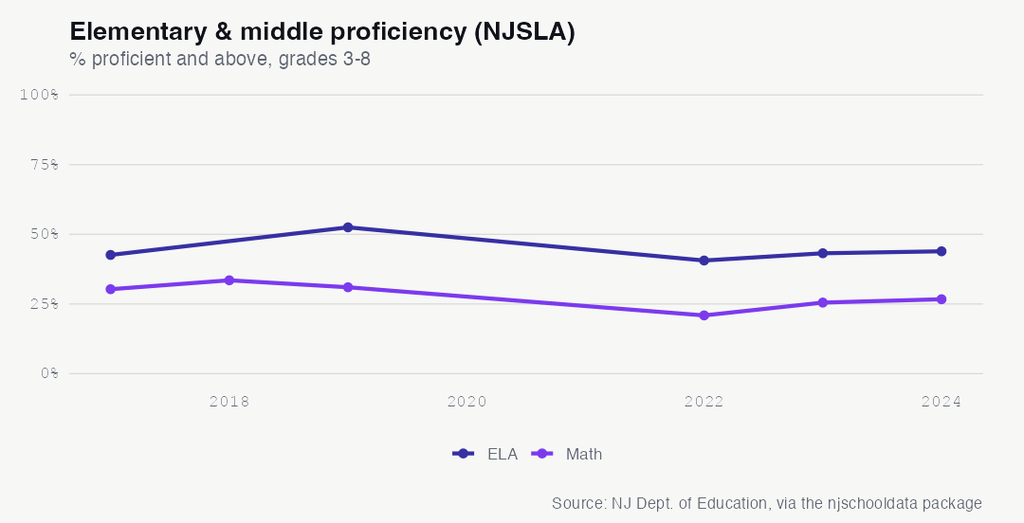

See the underlying data ›

No. 3 EQUITY

## Elizabeth’s Multilingual Population More Than Doubled to 11,057 Students, Now 41% of Enrollment

Students classified as multilingual learners grew from 4,435 (17.3%) in 2015 to 11,057 (41.4%) in 2026, even as the district’s NJSLA reading gap for current learners runs more than 24 points.

Elizabeth has become one of New Jersey’s most linguistically diverse large districts, and the shift has accelerated. The share of students classified as multilingual learners climbed from 17.3% in 2015 to 41.4% in 2026 — a jump from 4,435 students to 11,057. The count crossed 8,000 in 2024, then leapt past 10,000 in 2025, far outpacing the district’s overall enrollment changes.

The surge carries real instructional stakes. On the 2024 NJSLA in grades 3-8, students currently classified as multilingual learners reached 19.5% ELA proficiency, against 43.9% for all students — a gap of more than 24 points. Yet the same data shows the other end of the arc: former multilingual learners scored 83.2% proficient, the highest of any subgroup, suggesting students who exit language services go on to thrive.

The figures document a population transformation but not whether the district’s bilingual programming, staffing, and assessment supports are scaling at the same pace. With multilingual learners approaching half of all students, the question for families and the board is whether the path from 19.5% to 83.2% proficiency is reaching all of them or only some.

See the underlying data ›

No. 4 EQUITY

## Students With Disabilities Reach 14.8% NJSLA Reading Proficiency in Elizabeth — a 29-Point Gap

On the 2024 NJSLA in grades 3-8, students in special education were proficient in ELA at 14.8%, against 43.9% districtwide and 59.0% for white students.

Elizabeth’s grade 3-8 reading results reveal its widest internal divide along disability lines. On the 2024 NJSLA, students in special education reached 14.8% proficiency in English language arts — 29.1 points below the districtwide rate of 43.9%. Students receiving special education accommodations fared only marginally better at 17.9%.

By race and income, the gaps are narrower. White students were proficient at 59.0% and Asian students at 66.4%, while Hispanic students, the district’s largest group, sat near the average at 42.9% and students who are economically disadvantaged at 42.0%. The spread between the district’s highest and lowest racial subgroups is real but smaller than the chasm between students with and without disabilities.

The district’s deepest achievement gaps track disability status and language classification rather than race. The data marks where the gap is largest but cannot say what would close it — whether the 14.8% figure for students in special education reflects the test’s design, the supports in place, or the share of students for whom grade-level proficiency was never the immediate goal.

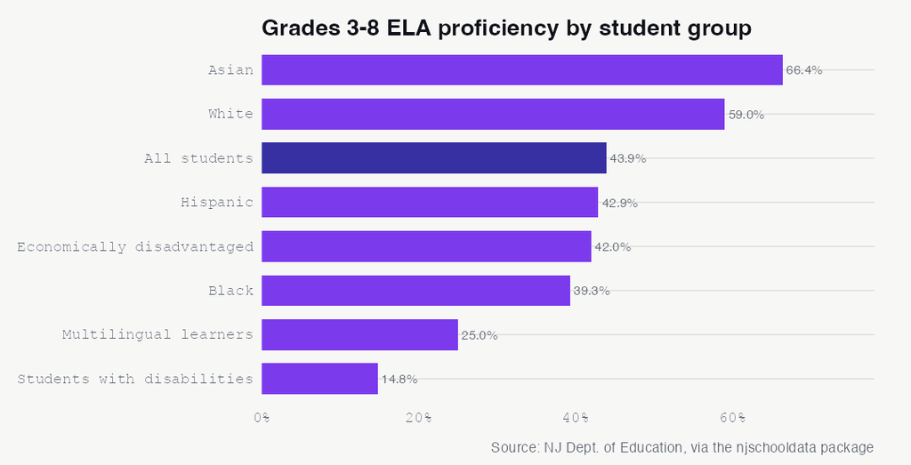

See the underlying data ›

No. 5 ATTENDANCE

## Chronic Absenteeism in Elizabeth Is 8 Points Below the DFG A Median — But Still Above Pre-COVID

In 2024, 15.8% of Elizabeth students were chronically absent, against a peer median of 24.1%, yet that remains above the district’s 11.9% in 2019.

Many high-poverty New Jersey districts are still struggling to get students back in seats after the pandemic, but Elizabeth has recovered faster than most of its peers. Its chronic absenteeism rate was 15.8% in 2024 — more than eight percentage points below the median of 24.1% among the 39 districts in its District Factor Group A peer group.

The district’s own trajectory shows the recovery is real but incomplete. Chronic absenteeism stood at 11.9% in 2019, spiked to 19.4% in 2022 as schools reopened, and has fallen each year since — to 16.9% in 2023 and 15.8% in 2024. That is a steep climb down from the peak, yet it still sits nearly four points above where the district was before COVID.

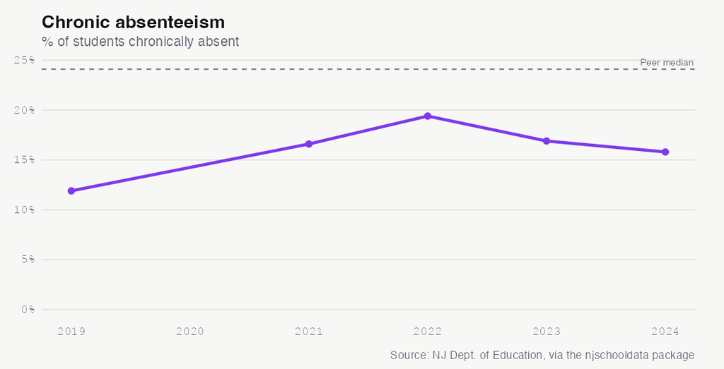

See the underlying data ›

No. 6 ENROLLMENT

## After a Decade of Growth, Elizabeth Enrollment Dropped by 1,272 Students in One Year

Enrollment peaked at 27,980 in 2025 and fell to 26,708 in 2026, a 4.5% one-year decline that reversed years of steady gains.

For most of the past decade, Elizabeth grew. Enrollment rose from 25,608 students in 2015 to a peak of 27,980 in 2025, adding students in nearly every year and barely flinching during the pandemic — the district lost just 145 students in 2021 and held above 27,500 through 2022. Then, in 2026, it fell by 1,272 students to 26,708, a 4.5% drop in a single year.

The enrollment table records the drop but not its cause, and one year does not make a trend. Whether 2026 marks a turning point for the state’s fourth-largest district or a single anomalous count is the question the next year’s figures will settle.

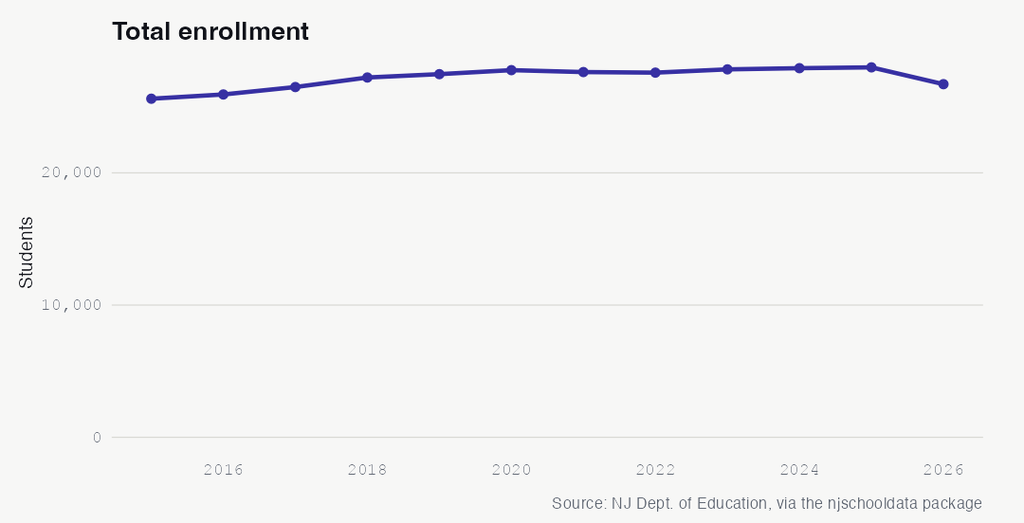

See the underlying data ›

No. 7 GRADUATION

## Elizabeth’s Graduation Rate Climbed Nearly 7 Points in Five Years to 88.4%

The four-year graduation rate rose from 81.6% in 2020 to 88.4% in 2025, landing the district in the 62nd percentile among DFG A peers.

Elizabeth’s four-year graduation rate has climbed almost without interruption, from 81.6% in 2020 to a peak of 89.0% in 2024 before settling at 88.4% in 2025. That five-year gain of nearly seven points moved the district above the median for its peer group: among the 39 districts in District Factor Group A, where the median graduation rate is 85.0%, Elizabeth now sits in the 62nd percentile.

The rise came as the graduating cohort grew. The 2025 class numbered 2,173 students, up from 1,877 in 2021 — meaning the district lifted its completion rate even as it pushed more students through to senior year. Each year from 2021 to 2024 set a new high before the slight dip in 2025.

The district has turned a below-peer graduation rate into an above-peer one in half a decade. Whether the small 2025 step back from 89.0% is noise or the start of a plateau is the question the next cohort will answer.

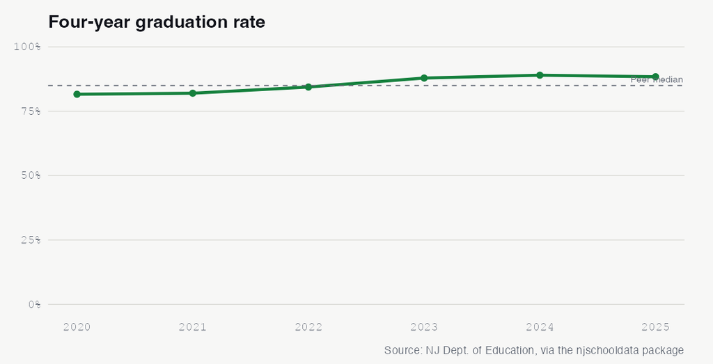

See the underlying data ›

No. 8 EQUITY

## Students With Disabilities Graduate at 74.7% in Elizabeth — Nearly 14 Points Below the District Average

In 2025, the four-year graduation rate was 74.7% for students with disabilities and 70.6% for students experiencing homelessness, against an 88.4% district rate.

Elizabeth’s overall graduation rate of 88.4% in 2025 masks wide gaps for its most vulnerable students. Students with disabilities graduated at 74.7% — 13.7 points below the district average — based on a cohort of 233. Students experiencing homelessness fared worse still, at 70.6% across a cohort of 51, the lowest rate among all reported subgroups.

The gaps by race and income, by contrast, are narrow. White students graduated at 89.8% and Black students at 87.5%, a difference of just 2.3 points, while students who are economically disadvantaged actually finished at 89.1% — slightly above the district average. Asian students led at 91.9% and Hispanic students, the district’s largest group, matched the overall rate at 88.4%. The district’s largest divides are not racial but tied to disability status and housing instability.

Elizabeth has nearly closed its racial and economic graduation gaps while two gaps remain stubborn. The data points to where the next push belongs but cannot say what it would take to bring students with disabilities and students experiencing homelessness up to the district’s overall mark.

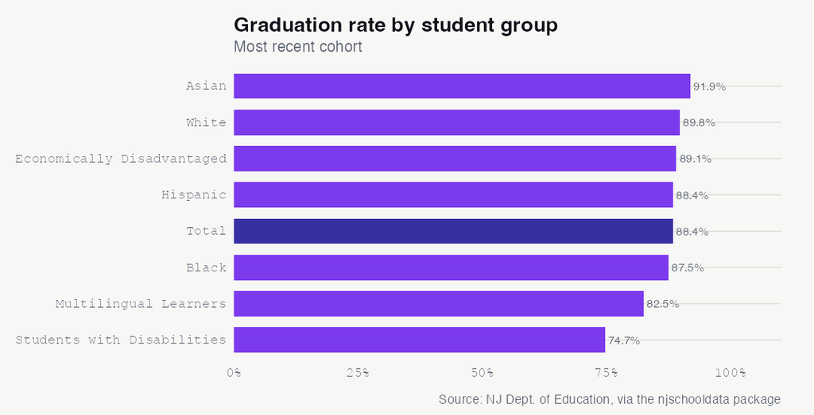

See the underlying data ›

No. 9 DEMOGRAPHICS

## Hispanic Students Now Make Up 77% of Elizabeth, Up 7 Points Since 2015

The Hispanic share of enrollment rose from 69.7% to 77.0% over eleven years as the Black share fell 5.2 points and the white share fell 1.9.

Elizabeth has long been a majority-Hispanic district, but the majority has deepened. The Hispanic share of enrollment rose from 69.7% in 2015 to 77.0% in 2026, a gain of 7.3 percentage points and the largest demographic shift in the district over that span. The increase came at the expense of the two next-largest groups: the Black share fell 5.2 points, from 20.3% to 15.1%, and the white share slipped from 8.0% to 6.1%.

The other groups barely register and have held steady. Asian enrollment hovered near 1.5% to 1.8% throughout, and the multiracial, Native American, and Pacific Islander shares each stayed at or below a fraction of a percent. The story of Elizabeth’s changing student body is almost entirely a story of a growing Hispanic majority and a shrinking Black population.

The figures track the composition but not what is driving it — births, migration, housing patterns, or charter and parochial choices. As the Hispanic share nears four in five students, the question is whether the district’s programming, including its rapidly growing multilingual services, is keeping pace with who its students are.

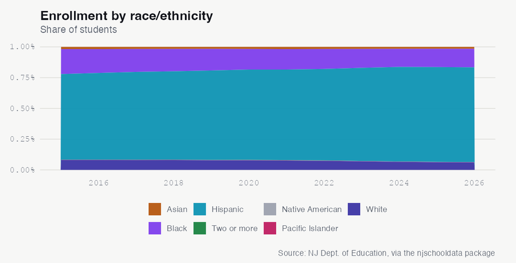

See the underlying data ›

No. 10 FINANCE

## Elizabeth Spends $20,203 per Pupil, Up 18% in a Decade, With 59 Cents of Every Dollar in Classrooms

Per-pupil spending rose from $17,137 in 2014 to $20,203 in 2024, a 17.9% increase that puts the district in the 61st percentile of its peer group.

Elizabeth’s per-pupil spending reached $20,203 in 2024, up 17.9% from $17,137 in 2014. That figure lands the district in the 61st percentile among its District Factor Group A peers, above the peer median of $19,338 — though the climb was not smooth. Spending actually dipped to $15,624 by 2016 before rising again, with the sharpest jumps coming in 2022 (to $18,697) and 2024.

Where the money goes tells its own story. In 2025, classroom instruction accounted for 58.8% of spending, with plant operations at 16.0%, support services at 15.9%, and administration at 8.1%. The district’s staffing ratios show 13 students per teacher but far thinner coverage elsewhere — 354 students per administrator, 472 per nurse, and 556 per counselor.

Elizabeth has moved from below to above its peer median on per-pupil spending over the decade while keeping nearly six of every ten dollars in the classroom. The figures show the inputs but not the leverage: whether the counselor and nurse ratios, well above the per-teacher figure, are where rising dollars get directed next.

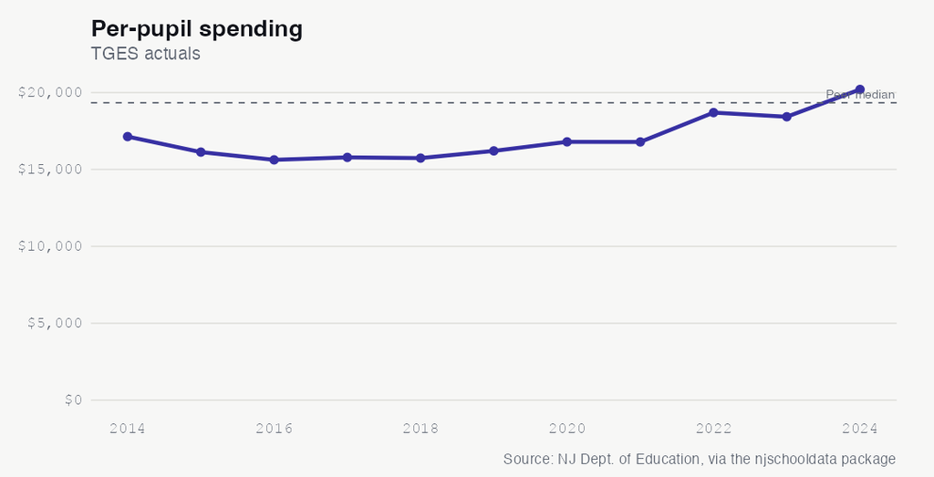

See the underlying data ›

## The Almanac

The full longitudinal record behind the stories above. Every number a reader can check.

### Enrollment (total)

| year | students | yoy | yoy_pct |
| --- | --- | --- | --- |
| 2015 | 25608 | NA | NA |
| 2016 | 25929 | 321 | 1.3 |
| 2017 | 26491 | 562 | 2.2 |
| 2018 | 27212 | 721 | 2.7 |
| 2019 | 27466 | 254 | 0.9 |
| 2020 | 27769 | 303 | 1.1 |
| 2021 | 27624 | -145 | -0.5 |
| 2022 | 27581 | -43 | -0.2 |
| 2023 | 27828 | 247 | 0.9 |
| 2024 | 27918 | 90 | 0.3 |
| 2025 | 27980 | 62 | 0.2 |
| 2026 | 26708 | -1272 | -4.5 |

### Demographic share (%) by year

| end_year | white | black | hispanic | asian | native_american | pacific_islander | multiracial |
| --- | --- | --- | --- | --- | --- | --- | --- |
| 2015 | 8 | 20.3 | 69.7 | 1.8 | 0 | 0.2 | 0 |
| 2016 | 8 | 19.4 | 70.6 | 1.8 | 0 | 0.2 | 0 |
| 2017 | 7.9 | 18.7 | 71.5 | 1.7 | 0 | 0.2 | 0 |
| 2018 | 8 | 18.2 | 72 | 1.7 | 0 | 0.2 | 0 |
| 2019 | 7.8 | 17.6 | 72.7 | 1.6 | 0 | 0.2 | 0.1 |
| 2020 | 7.8 | 16.8 | 73.4 | 1.7 | 0 | 0.2 | 0.1 |
| 2021 | 7.6 | 16.6 | 73.6 | 1.8 | 0 | 0.2 | 0.1 |
| 2022 | 7.4 | 16.3 | 74.3 | 1.7 | 0.1 | 0.2 | 0.1 |
| 2023 | 7 | 15.4 | 75.8 | 1.7 | 0.1 | 0.1 | 0 |
| 2024 | 6.5 | 14.7 | 77 | 1.6 | 0.1 | 0.1 | 0 |
| 2025 | 6.3 | 14.9 | 77.1 | 1.5 | 0.1 | 0.2 | 0 |
| 2026 | 6.1 | 15.1 | 77 | 1.5 | 0.1 | 0.1 | 0 |

### Special populations (LEP, FRL)

| end_year | subgroup | students | pct |
| --- | --- | --- | --- |
| 2015 | lep | 4435 | 17.3 |
| 2015 | free_reduced_lunch | 21035 | 82.1 |
| 2016 | lep | 4594 | 17.7 |
| 2016 | free_reduced_lunch | 22169 | 85.5 |
| 2017 | lep | 4955 | 18.7 |
| 2017 | free_reduced_lunch | 22115 | 83.5 |
| 2018 | lep | 5118 | 18.8 |
| 2018 | free_reduced_lunch | 22019 | 80.9 |
| 2019 | lep | 5103 | 18.6 |
| 2019 | free_reduced_lunch | 22102 | 80.5 |
| 2020 | lep | 5582 | 20.1 |
| 2020 | free_reduced_lunch | 22021 | 79.3 |
| 2021 | lep | 5939 | 21.5 |
| 2021 | free_reduced_lunch | 19558 | 70.8 |
| 2022 | lep | 6564 | 23.8 |
| 2022 | free_reduced_lunch | 18176 | 65.9 |
| 2023 | lep | 7402 | 26.6 |
| 2023 | free_reduced_lunch | 21845 | 78.5 |
| 2024 | lep | 8264 | 29.6 |
| 2024 | free_reduced_lunch | 22279 | 79.8 |
| 2025 | lep | 10688 | 38.2 |
| 2025 | free_reduced_lunch | 22915 | 81.9 |
| 2026 | lep | 11057 | 41.4 |
| 2026 | free_reduced_lunch | 22034 | 82.5 |

### Graduation rate 4yr (total)

| year | grad_rate | cohort |
| --- | --- | --- |
| 2020 | 81.6 | 2011 |
| 2021 | 82 | 1877 |
| 2022 | 84.4 | 1880 |
| 2023 | 87.9 | 1853 |
| 2024 | 89 | 2024 |
| 2025 | 88.4 | 2173 |

### Graduation by subgroup (2025)

| subgroup | grad_rate | cohort |
| --- | --- | --- |
| asian | 91.9 | 37 |
| female | 91.7 | NA |
| white | 89.8 | 127 |
| economically disadvantaged | 89.1 | 1944 |
| total | 88.4 | 2173 |
| hispanic | 88.4 | 1674 |
| black | 87.5 | 335 |
| male | 85.2 | 1125 |
| multilingual learners | 82.5 | 639 |
| students with disabilities | 74.7 | 233 |
| students experiencing homelessness | 70.6 | 51 |
| american indian | NA | NA |
| migrant students | NA | NA |
| military-connected students | NA | NA |
| non-binary/undesignated gender | NA | NA |
| students in foster care | NA | NA |
| multiracial | NA | NA |

### NJGPA high-school proficiency (% proficient+)

| year | test | prof_above | valid |
| --- | --- | --- | --- |
| 2023 | ela | 73.4 | 1645 |
| 2023 | math | 39.6 | 1761 |
| 2024 | ela | 72.6 | 2091 |
| 2024 | math | 41.7 | 2071 |
| 2025 | ela | 71.2 | 1902 |
| 2025 | math | 48.3 | 1902 |

### NJGPA ELA by subgroup (2025)

[output not shown]

### NJSLA grades 3-8 proficiency (% proficient+, enrollment-weighted across grades)

| testing_year | test_name | prof |
| --- | --- | --- |
| 2017 | ela | 42.6 |
| 2017 | math | 30.3 |
| 2018 | math | 33.5 |
| 2019 | ela | 52.5 |
| 2019 | math | 31.0 |
| 2022 | ela | 40.6 |
| 2022 | math | 20.9 |
| 2023 | ela | 43.2 |
| 2023 | math | 25.5 |
| 2024 | ela | 43.9 |
| 2024 | math | 26.7 |

### NJSLA ELA proficiency by subgroup (2024, grades 3-8)

| subgroup | prof |
| --- | --- |
| lep_former | 83.2 |
| FORMER - ML | 75.7 |
| asian | 66.4 |
| white | 59.0 |
| non_ed | 48.6 |
| female | 46.7 |
| total_population | 43.9 |
| hispanic | 42.9 |
| ed | 42.0 |
| male | 40.5 |
| black | 39.3 |
| lep_current_former | 37.7 |
| MULTILINGUAL LEARNERS | 25.0 |
| lep_current | 19.5 |
| sped_accomodations | 17.9 |
| CURRENT - ML | 16.4 |
| special_education | 14.8 |

### Chronic absenteeism (% chronically absent)

| year | chronic_pct |
| --- | --- |
| 2019 | 11.9 |
| 2021 | 16.6 |
| 2022 | 19.4 |
| 2023 | 16.9 |
| 2024 | 15.8 |

### Disciplinary removals

[output not shown]

### Police notifications (incident counts)

| year | violence | weapons | vandalism | substances | hib | other |
| --- | --- | --- | --- | --- | --- | --- |
| 2019 | 31 | 34 | 11 | 65 | 5 | 9 |
| 2020 | 28 | 16 | 7 | 53 | 8 | 6 |
| 2021 | 0 | 0 | 0 | 1 | 0 | 0 |
| 2022 | 85 | 62 | 13 | 224 | 23 | 20 |
| 2023 | 70 | 53 | 9 | 223 | 30 | 36 |
| 2024 | 55 | 17 | 14 | 86 | 31 | 29 |

### HIB (harassment/intimidation/bullying) investigations

| end_year | alleged | confirmed |
| --- | --- | --- |
| 2019 | 318 | 182 |
| 2020 | 194 | 113 |
| 2021 | 34 | 23 |
| 2022 | 398 | 281 |
| 2023 | 368 | 235 |
| 2024 | 275 | 223 |

### SAT participation (% of grade)

| year | sat_part | state_sat |
| --- | --- | --- |
| 2018 | 99.1 | 72.2 |
| 2019 | 100 | 72.1 |
| 2020 | 100 | 71.1 |
| 2021 | 100 | 45.4 |
| 2022 | 100 | 60.8 |
| 2023 | 100 | 61.9 |
| 2024 | 100 | 62.7 |

### AP/IB & dual enrollment (% of students)

| year | apib_coursework | apib_exam | ap3_ib4 | state_ap3_ib4 | dual |
| --- | --- | --- | --- | --- | --- |
| 2018 | 100 | 96.2 | 48.1 | 20.5 | 0 |
| 2019 | 97.5 | 92.9 | 48.9 | 20.7 | 28.4 |
| 2020 | 94.8 | 87.3 | 56.1 | 22.8 | 14.2 |
| 2021 | 100 | 93.3 | 30.8 | 17.9 | 0 |
| 2022 | 99.7 | 96.2 | 40.3 | 19.9 | 0 |
| 2023 | 89.8 | 86.1 | 44.5 | 21.3 | 0 |
| 2024 | 87.5 | 86.5 | 52.9 | 23 | 0 |

### Special education (raw rows; inspect for classification rate)

| end_year | district_id |
| --- | --- |
| 2024 | 1320 |

### Per-pupil spending (TGES actuals)

| year | per_pupil | rank | ade |
| --- | --- | --- | --- |
| 2014 | 17137 | 92 | 24774 |
| 2015 | 16128 | 89 | 25674 |
| 2016 | 15624 | 74 | 25994 |
| 2017 | 15785 | 71 | 26678 |
| 2018 | 15738 | 59 | 27233 |
| 2019 | 16207 | 56 | 27453 |
| 2020 | 16795 | 65 | 27668 |
| 2021 | 16789 | 59 | 26904 |
| 2022 | 18697 | 75 | 27066 |
| 2023 | 18426 | 56 | 27532 |
| 2024 | 20203 | 70 | 27729 |

### Spending composition shares (2025)

| classroom_share | support_services_share | administration_share | plant_ops_share | food_service_share | extracurricular_share | equipment_share |
| --- | --- | --- | --- | --- | --- | --- |
| 58.8 | 15.9 | 8.1 | 16 | NA | 0.8 | 0 |

### Staffing ratios

| end_year | student_teacher_district | student_admin_district | student_counselor_district | student_nurse_district |
| --- | --- | --- | --- | --- |
| 2024 | 13:1 | 354:1 | 556:1 | 472:1 |

Back to top